# Fact Checking BLS

Author

Sebastian Alejos

Published

December 7, 2025

## Task 1: Data Acquisition

```r
library(httr2)
library(rvest)
library(dplyr)
library(tidyr)
library(stringr)
library(lubridate)
library(purrr)

# STEP 1 — Send POST request
resp <- request("https://data.bls.gov/pdq/SurveyOutputServlet") %>%
  req_method("POST") %>%
  req_body_form(
    request_action = "get_data",
    reformat = "true",
    from_results_page = "true",
    from_year = "1979",
    to_year = "2025",
    initial_request = "false",
    data_tool = "surveymost",
    series_id = "CES0000000001",
    original_annualAveragesRequested = "false"
  ) %>%
  req_perform()

# STEP 2 — Extract table
tbl <- resp_body_html(resp) %>%
  html_elements("table") %>%
  map(~ html_table(.x, fill = TRUE)) %>%
  keep(~ ncol(.x) > 5) %>%
  first()

# STEP 3 — Clean + reshape
df_levels <- tbl %>%
  filter(str_detect(Year, "^[0-9]{4}$")) %>%        # keep only numeric years
  mutate(Year = as.integer(Year)) %>%
  pivot_longer(
    cols = -Year,
    names_to = "month",
    values_to = "level"
  ) %>%
  mutate(
    month = str_sub(month, 1, 3),                   # abbreviations like Jan, Feb
    month_num = match(month, month.abb),            # convert to numeric month
    date  = make_date(Year, month_num, 1),          # build proper Date
    level = as.numeric(str_replace_all(level, ",", ""))
  ) %>%
  drop_na(date, level) %>%
  arrange(date) %>%
  select(date, level)

df_levels
```

```
# A tibble: 559 × 2
   date       level
   <date>     <dbl>
 1 1979-01-01 88808
 2 1979-02-01 89055
 3 1979-03-01 89479
 4 1979-04-01 89417
 5 1979-05-01 89789
 6 1979-06-01 90108
 7 1979-07-01 90217
 8 1979-08-01 90300
 9 1979-09-01 90327
10 1979-10-01 90481
# ℹ 549 more rows
```

## Task 2: Data Cleaning

```r
# ---- Load packages ----
library(httr2)
library(rvest)
library(dplyr)
library(purrr)
library(stringr)
library(lubridate)

# ---- Request page using realistic browser headers ----
resp <- request("https://www.bls.gov/web/empsit/cesnaicsrev.htm") %>%
  req_headers(
    "user-agent" = "Mozilla/5.0 (Macintosh; Intel Mac OS X 10_15_7) AppleWebKit/537.36 (KHTML, like Gecko) Chrome/120.0.0.0 Safari/537.36",
    "accept" = "text/html,application/xhtml+xml,application/xml;q=0.9,*/*;q=0.8",
    "accept-language" = "en-US,en;q=0.5",
    "cache-control" = "no-cache",
    "referer" = "https://www.bls.gov/web/empsit/cesnaicsrev.htm"
  ) %>%
  req_perform()

html <- resp_body_html(resp)

# ---- Extraction function with dynamic format handling ----
extract_year <- function(year, html) {

  tbl_node <- html %>% html_element(paste0("#", year))

  if (inherits(tbl_node, "xml_missing")) {
    return(tibble(
      Date = as.Date(character()),
      Original = numeric(),
      Final = numeric(),
      Revision = numeric()
    ))
  }

  tbl <- tbl_node %>%
    html_element("tbody") %>%
    html_table(fill = TRUE, header = FALSE) %>%
    slice(1:12) %>%
    select(month = 1, Original = 3, Final = 5) %>%
    mutate(
      Original = as.numeric(gsub("[^0-9-]", "", Original)),
      Final    = as.numeric(gsub("[^0-9-]", "", Final)),
      Date     = ym(paste(year, month)),
      Revision = Final - Original
    ) %>%
    select(Date, Original, Final, Revision)

  return(tbl)
}

# ---- Detect Available Year Tables ----
available_years <- html %>%
  html_elements("table") %>%
  html_attr("id") %>%
  suppressWarnings(as.numeric()) %>%
  na.omit() %>%
  sort()

# ---- Apply Function to Each Year ----
df_revisions <- map_df(available_years, extract_year, html = html)

# ---- Final Results ----
df_revisions
```

```
# A tibble: 570 × 4
   Date       Original Final Revision
   <date>        <dbl> <dbl>    <dbl>
 1 1979-01-01      325   243      -82
 2 1979-02-01      301   294       -7
 3 1979-03-01      324   445      121
 4 1979-04-01       72   -15      -87
 5 1979-05-01      171   291      120
 6 1979-06-01       97   225      128
 7 1979-07-01       44    87       43
 8 1979-08-01        2    49       47
 9 1979-09-01      135    41      -94
10 1979-10-01      306   179     -127
# ℹ 560 more rows
```

## Task 3: Data Merging and Exploration

```r
df_joined <- df_levels %>%
  left_join(df_revisions, by = c("date" = "Date"))
```

# Largest Revisions Positive and Negative in CES History

```r
# Largest positive revision
largest_pos <- df_joined %>%
  filter(!is.na(Revision)) %>%
  slice_max(Revision, n = 1, with_ties = FALSE)

# Largest negative revision
largest_neg <- df_joined %>%
  filter(!is.na(Revision)) %>%
  slice_min(Revision, n = 1, with_ties = FALSE)

largest_pos
```

```
# A tibble: 1 × 5
  date        level Original Final Revision
  <date>      <dbl>    <dbl> <dbl>    <dbl>
1 2021-11-01 149206      210   647      437
```

```r
largest_neg
```

```
# A tibble: 1 × 5
  date        level Original Final Revision
  <date>      <dbl>    <dbl> <dbl>    <dbl>
1 2020-03-01 150895     -701 -1373     -672
```

The Timeline scatter emphasizes when these extreme revisions happened.

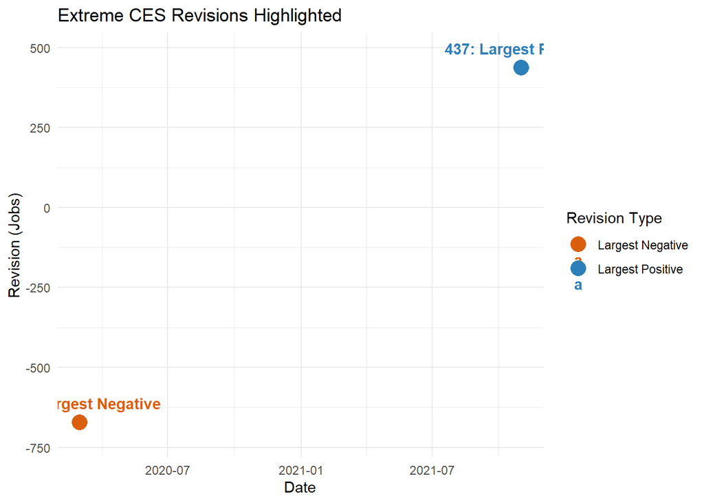

```r
library(ggplot2)
library(dplyr)

# Combine the two extreme points
extremes <- bind_rows(
  largest_pos %>% mutate(type = "Largest Positive"),
  largest_neg %>% mutate(type = "Largest Negative")
)

# Create a label column with clean formatting
extremes <- extremes %>%
  mutate(label = paste0(Revision, ": ", type))

# Plot
ggplot(extremes, aes(x = date, y = Revision, color = type)) +
  geom_point(size = 5) +
  geom_text(aes(label = label), vjust = -1.2, fontface = "bold") +
  scale_color_manual(values = c("Largest Positive" = "#2C7FB8", "Largest Negative" = "#D95F0E")) +
  scale_y_continuous(limits = c(min(extremes$Revision) - 50 , max(extremes$Revision) + 50)) +
  labs(
    title = "Extreme CES Revisions Highlighted",
    x = "Date",
    y = "Revision (Jobs)",
    color = "Revision Type"
  ) +
  theme_minimal()
```

Average revision magnitude (Average and percent of level)

Average absolute revision is about 56 thousand jobs. This mean on average, the monthly CES estimate is later revised by 56,600 jobs.

Average percent revision: about 0.048% of the employment level. Revisions are typically very small relative to the overall size of the labor market less than one-twentieth of one percent.

Revisions are noticable in raw counts but proportionally modest.

```r
avg_stats <- df_joined %>%
  mutate(
    abs_revision = abs(Revision),
    pct_revision = abs(Revision) / level
  ) %>%
  summarise(
    avg_abs_revision = mean(abs_revision, na.rm = TRUE),
    avg_pct_revision = mean(pct_revision, na.rm = TRUE)
  )

avg_stats
```

```
# A tibble: 1 × 2
  avg_abs_revision avg_pct_revision
             <dbl>            <dbl>
1             56.6         0.000481
```

Visualizing the Average Revision Magnitude

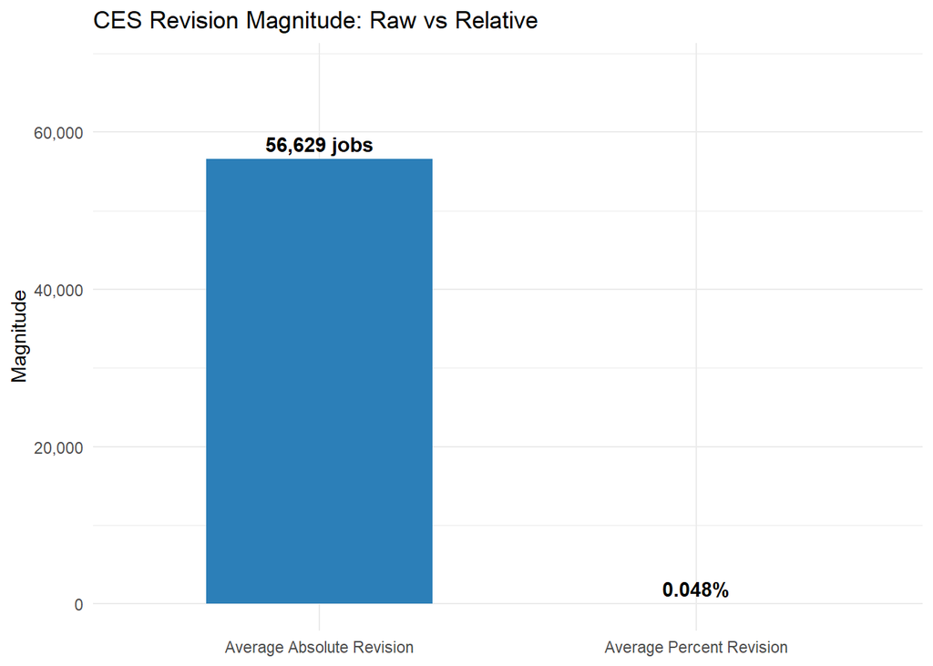

```r
library(ggplot2)
library(dplyr)
library(scales)

# Create a summary tibble
avg_stats <- tibble(
  Metric = c("Average Absolute Revision", "Average Percent Revision"),
  Value = c(56629.23, 0.0004809862)
)

# Format labels for display
avg_stats <- avg_stats %>%
  mutate(
    Display = c("56,629 jobs", "0.048%"),
    Metric = factor(Metric, levels = c("Average Absolute Revision", "Average Percent Revision"))
  )

# Plot
ggplot(avg_stats, aes(x = Metric, y = Value, fill = Metric)) +
  geom_col(width = 0.6, show.legend = FALSE) +
  geom_text(aes(label = Display), vjust = -0.5, fontface = "bold") +
  scale_y_continuous(
    labels = comma,
    limits = c(0, max(avg_stats$Value) * 1.2)
  ) +
  scale_fill_manual(values = c("#2C7FB8", "#FDBF6F")) +
  labs(
    title = "CES Revision Magnitude: Raw vs Relative",
    x = NULL,
    y = "Magnitude"
  ) +
  theme_minimal()
```

# Median Absolute Revision by Decade

The y-axis displays the median absolute revision in jobs - the middle value of monthly revision magnitudes (ignoring direction). Whereas the x-axis represents the decades starting from 1970s til the 2020s.

Based on the line graph we see that revisions are clearly largest during the 1970s (median of approx. 97 thousand jobs). The time frame between the 1980s to 2010s there was a steady decline in revision size, reaching a low of ~29 thousand jobs in the 2010s. The 2020s had increased revisions again with a median of approx. 49 thousand jobs.

The decline of the 2010s suggests improved initial accuracy in CES estimates over time. The uptick of the 2020s reflects the pandemic-related volatility or possible structural data collection methods.

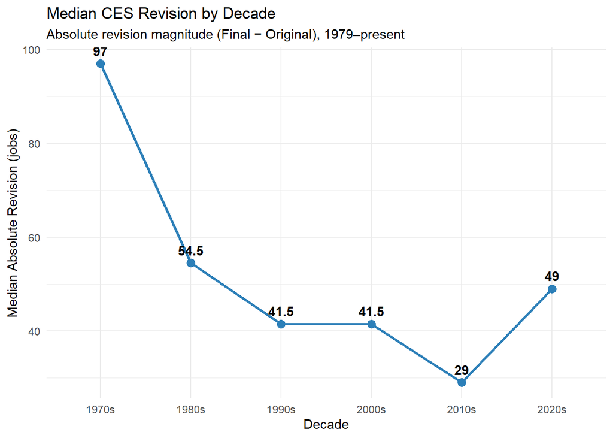

```r
library(dplyr)
library(ggplot2)

# Step 1: Create decade variable and compute median absolute revision
median_decade <- df_joined %>%
  filter(!is.na(Revision)) %>%
  mutate(
    abs_revision = abs(Revision),
    decade = paste0(floor(lubridate::year(date) / 10) * 10, "s")
  ) %>%
  group_by(decade) %>%
  summarise(median_abs_revision = median(abs_revision, na.rm = TRUE)) %>%
  ungroup() %>%
  mutate(decade = factor(decade, levels = sort(unique(decade))))

# Step 2: Plot
ggplot(median_decade, aes(x = decade, y = median_abs_revision, group = 1)) +
  geom_line(color = "#2C7FB8", linewidth = 1) +
  geom_point(color = "#2C7FB8", size = 3) +
  geom_text(aes(label = round(median_abs_revision, 1)), vjust = -0.8, fontface = "bold") +
  labs(
    title = "Median CES Revision by Decade",
    subtitle = "Absolute revision magnitude (Final − Original), 1979–present",
    x = "Decade",
    y = "Median Absolute Revision (jobs)"
  ) +
  theme_minimal()
```

# Time Series Model on the Fraction of Positive Revisions

The time series model demonstrates how often monthly employment revisions were in an upward trend across the past 45 years. Precisely the green line with dots shows yearly fraction of months with upward revisions. While the blue line shows the smoothed trend using LOESS (Locally Estimated Scatterplot Smoothing - creating a parametric technique that draws smooth curves through noisy data) showing long term shifts. The Dashed line represents a 50% neutral benchmark above means upward revisions dominate.

```r
library(dplyr)
library(lubridate)

frac_year <- df_joined %>%
  filter(!is.na(Revision)) %>%
  mutate(year = year(date)) %>%
  group_by(year) %>%
  summarise(frac_positive = mean(Revision > 0, na.rm = TRUE)) %>%
  ungroup()
```

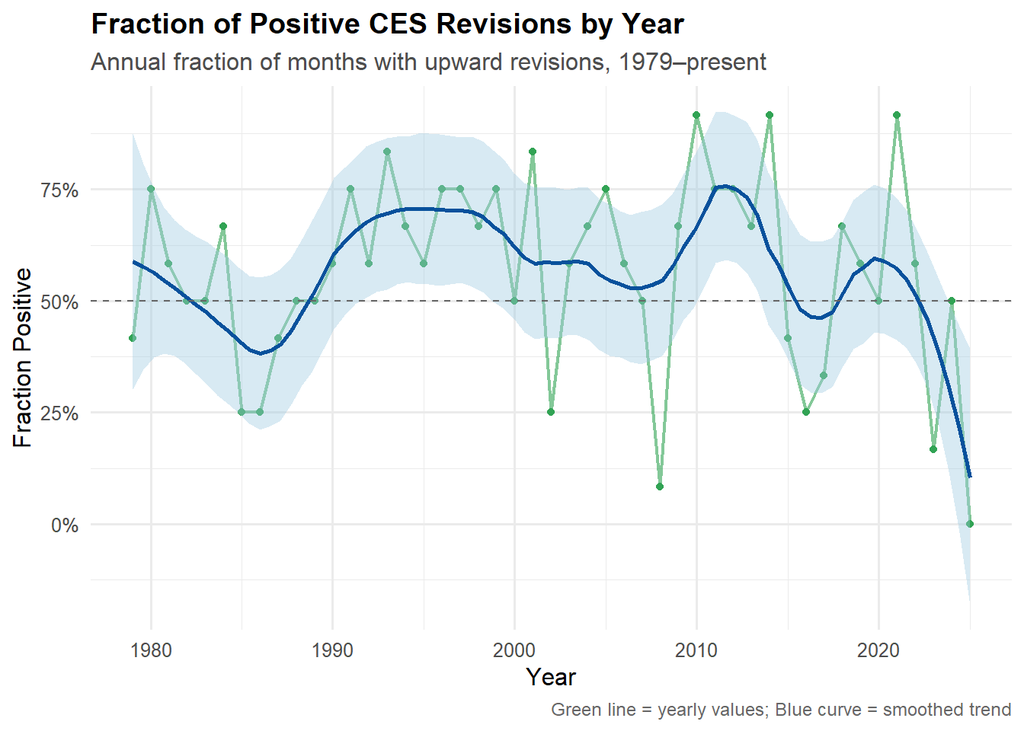

```r
library(ggplot2)
library(dplyr)
library(scales)

# Assuming frac_year has columns: year, frac_positive
ggplot(frac_year, aes(x = year, y = frac_positive)) +
  # Raw yearly line
  geom_line(color = "#31A354", linewidth = 0.8, alpha = 0.6) +

  # Add points for each year
  geom_point(color = "#31A354", size = 1.5) +

  # Add a smooth trend line (loess)
  geom_smooth(method = "loess", span = 0.3, color = "#08519C", fill = "#9ecae1") +

  # Add horizontal reference line at 50%
  geom_hline(yintercept = 0.5, linetype = "dashed", color = "grey40") +

  # Labels and formatting
  labs(
    title = "Fraction of Positive CES Revisions by Year",
    subtitle = "Annual fraction of months with upward revisions, 1979–present",
    x = "Year",
    y = "Fraction Positive",
    caption = "Green line = yearly values; Blue curve = smoothed trend"
  ) +
  scale_y_continuous(labels = percent_format(accuracy = 1)) +
  theme_minimal(base_size = 12) +
  theme(
    plot.title = element_text(face = "bold"),
    plot.subtitle = element_text(color = "grey30"),
    plot.caption = element_text(size = 9, color = "grey40")
  )
```

## Task 4: Statisical Inference

# Has the fraction of negative revisions increased post-2000?

Pre-2000 proportion of negative revisions (pro 1) ~ 40.5% Post-2000 proportion of negative revisions (prop 2) ~ 44.0% The p-value is far above the 0.05 statistical threshold. Although the raw proportion of negative revisions is slightly higher after 2000, the difference shows not statistically significant. There is no evidence of negative CES revisions has increased post-2000 in a statistically meaningful manner.

```r
df_joined <- df_joined %>%
  mutate(year = lubridate::year(date))

pre2000 <- sum(df_joined$Revision < 0 & df_joined$year < 2000, na.rm = TRUE)
pre2000_n <- sum(df_joined$year < 2000, na.rm = TRUE)

post2000 <- sum(df_joined$Revision < 0 & df_joined$year >= 2000, na.rm = TRUE)
post2000_n <- sum(df_joined$year >= 2000, na.rm = TRUE)

prop_test_neg <- prop.test(c(pre2000, post2000), c(pre2000_n, post2000_n))
prop_test_neg
```

```
    2-sample test for equality of proportions with continuity correction

data:  c(pre2000, post2000) out of c(pre2000_n, post2000_n)
X-squared = 0.57339, df = 1, p-value = 0.4489
alternative hypothesis: two.sided
95 percent confidence interval:
 -0.12104366  0.05030857
sample estimates:
   prop 1    prop 2
0.4047619 0.4401294
```

# Has the fraction of revisions >1% increased post 2020?

Based on the results of the 2 prop test, there are no months before or after 2020 in which CES revisions exceeded 1% of the unemployment level. The fratcion of revisions greater than 1% did not increase post 2020.

```r
df_joined <- df_joined %>%
  mutate(pct_revision = abs(Revision) / level)

pre2020 <- sum(df_joined$pct_revision > 0.01 & df_joined$year < 2020, na.rm = TRUE)
pre2020_n <- sum(df_joined$year < 2020, na.rm = TRUE)

post2020 <- sum(df_joined$pct_revision > 0.01 & df_joined$year >= 2020, na.rm = TRUE)
post2020_n <- sum(df_joined$year >= 2020, na.rm = TRUE)

prop_test_pct <- prop.test(c(pre2020, post2020), c(pre2020_n, post2020_n))
prop_test_pct
```

```
    2-sample test for equality of proportions without continuity correction

data:  c(pre2020, post2020) out of c(pre2020_n, post2020_n)
X-squared = NaN, df = 1, p-value = NA
alternative hypothesis: two.sided
95 percent confidence interval:
 0 0
sample estimates:
prop 1 prop 2
     0      0
```

# Is the average revision significantly different from zero?

The test below shows that the average CES revision statistically significantly different from zero. On average, monthly revisions are positive, meaning the final employment estimates tend to be higher than the original preliminary release.

The confidence interval that the true mean revision is between about +4,600 and +18,400 jobs.

While the magnitude is modest relative to the total employment level, the direction is clear: revisions generally add jobs rather than subtract them.

The CES exhibits a small but statistically significant upward bias in revisions over the past 45 years.

```r
t_test_zero <- t.test(df_joined$Revision, mu = 0)
t_test_zero
```

```
    One Sample t-test

data:  df_joined$Revision
t = 3.269, df = 560, p-value = 0.001146
alternative hypothesis: true mean is not equal to 0
95 percent confidence interval:
  4.578296 18.362881
sample estimates:
mean of x
 11.47059
```

# Has the average revision increased post-2020?

Based on the Welch Two Sample T Test, there is no evidence that the average CES revision increased post 2020. The p -value of 0.475 is greater than the statistically significant threshold . The confidence interval is wide including both negative and positive values, representing the true difference being either a decrease, an increase or no change at all.

```r
pre2020_vals <- df_joined$Revision[df_joined$year < 2020]
post2020_vals <- df_joined$Revision[df_joined$year >= 2020]

t_test_post2020 <- t.test(post2020_vals, pre2020_vals)
t_test_post2020
```

```
    Welch Two Sample t-test

data:  post2020_vals and pre2020_vals
t = -0.71849, df = 73.168, p-value = 0.4747
alternative hypothesis: true difference in means is not equal to 0
95 percent confidence interval:
 -46.30206  21.76300
sample estimates:
 mean of x  mean of y
 0.7101449 12.9796748
```

# Are revisions larger when CES changes are larger?

```r
df_joined <- df_joined %>%
  arrange(date) %>%
  mutate(level_change = level - dplyr::lag(level),
         abs_change = abs(level_change),
         abs_revision = abs(Revision))

# Define large change threshold
threshold <- quantile(df_joined$abs_change, 0.75, na.rm = TRUE)

df_joined <- df_joined %>%
  mutate(change_group = if_else(abs_change >= threshold, "large", "not"))

# Two-sample t-test
t_test_large_change <- t.test(abs_revision ~ change_group, data = df_joined)
t_test_large_change
```

```
    Welch Two Sample t-test

data:  abs_revision by change_group
t = 4.0491, df = 159.89, p-value = 7.995e-05
alternative hypothesis: true difference in means between group large and group not is not equal to 0
95 percent confidence interval:
 17.08524 49.62046
sample estimates:
mean in group large   mean in group not
           81.53901            48.18616
```

```r
# Correlation test
cor_test <- cor.test(df_joined$abs_change, df_joined$abs_revision, use = "complete.obs")
cor_test
```

```
    Pearson's product-moment correlation

data:  df_joined$abs_change and df_joined$abs_revision
t = 4.6221, df = 558, p-value = 4.724e-06
alternative hypothesis: true correlation is not equal to 0
95 percent confidence interval:
 0.1109354 0.2705772
sample estimates:
      cor
0.1920263
```

# Task 5

# Comments from Trump regaridng the CES Revisions

Based on Politifact: “None of these were close in scale to the 800,000 or 900,000 figures that Trump repeated. The revisions released in November 2024, for the September and October 2024 employment data, ranged from a decrease in 15,000 jobs to a gain of 49,000 jobs. The revisions released in December 2024, for the October and November 2024 employment data, were all increases ranging from 16,000 to 67,000 jobs.”

The “818,000” figure refers to an annual benchmark preliminary estimate announced in August 2024, not a partisan manipulation after the election; the final benchmark came in at 598,000. Monthly revisions around Nov–Dec 2024 were small (tens of thousands), not hundreds of thousands.

Benchmark Stats summarizes the revisions acorss the benchmark window (Apr 2023 - Mar 2024) to illustrate the scale similar to BLS benchmark discussion.

```r
library(dplyr)
library(lubridate)

# Assumes df_joined has columns: date (Date), Original (numeric), Final (numeric), Revision (numeric)
# Revision should be Final - Original per month.

benchmark_window <- df_joined %>%
  filter(date >= as.Date("2023-04-01"), date <= as.Date("2024-03-31"))

benchmark_stats <- benchmark_window %>%
  summarise(
    total_revision = sum(Revision, na.rm = TRUE),
    mean_monthly_revision = mean(Revision, na.rm = TRUE),
    mean_abs_monthly_revision = mean(abs(Revision), na.rm = TRUE),
    n_months = n()
  )

benchmark_stats
```

```
# A tibble: 1 × 4
  total_revision mean_monthly_revision mean_abs_monthly_revision n_months
           <dbl>                 <dbl>                     <dbl>    <int>
1           -362                 -30.2                      51.8       12
```

Key Takeaway from the benchmark Statistics: Based on the table total revisions (Apr 2023 - Mar 2024 window): - 362,000 jobs (revisions summed to a net downward adjustment of 362k)

Mean monthly revision: - 30,167 jobs (on average each in month in that window was revised downward by about 30K)

Claimed preliminary revision by Trump: 818,000 (Aug 2024), final benchmark of 598,000 (Feb 2025). The computed revision - 362,000 total. The computation confirms the downward revisions occurred, but the scale is far below the 800k -900k figures claimed by Trump.

# Graph Comparing the Claimed vs Actual Revisions:

The visual representation below demonstrates the claimed preliminary (818k) the figure Trump cited. The Final benchmark (598k), and the computer benchmark proxy (362k) reinforces the statement that the true adjustment was far below 800k-900k claimed. Monthly revisions near the election were modest at best, supporting the claim trump made overstated routine changes.

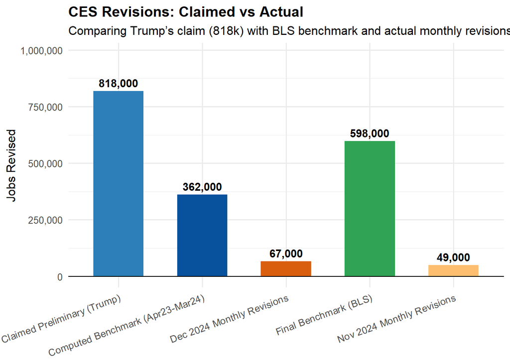

```r
library(ggplot2)

# Comparison dataset (treat negative as magnitude for clarity)
revision_compare <- data.frame(
  Category = c("Claimed Preliminary (Trump)",
               "Final Benchmark (BLS)",
               "Computed Benchmark (Apr23-Mar24)",
               "Nov 2024 Monthly Revisions",
               "Dec 2024 Monthly Revisions"),
  Value = c(818000, 598000, abs(-362000), 49000, 67000)
)

# Plot
ggplot(revision_compare, aes(x = Category, y = Value, fill = Category)) +
  geom_col(width = 0.6, show.legend = FALSE) +
  geom_text(aes(label = scales::comma(Value)), vjust = -0.5, fontface = "bold") +
  scale_fill_manual(values = c("#2C7FB8", "#08519C", "#D95F0E", "#31A354", "#FDBF6F")) +
  scale_y_continuous(
    limits = c(0, max(revision_compare$Value) * 1.2),  # zoom fit
    labels = scales::comma
  ) +
  geom_hline(yintercept = 0, linetype = "solid", color = "black") +  # reference line at 0
  labs(
    title = "CES Revisions: Claimed vs Actual",
    subtitle = "Comparing Trump’s claim (818k) with BLS benchmark and actual monthly revisions",
    x = NULL,
    y = "Jobs Revised"
  ) +
  theme_minimal(base_size = 12) +
  theme(
    plot.title = element_text(face = "bold"),
    axis.text.x = element_text(angle = 20, hjust = 1)
  )
```

# Job reports have gone up since the firing of Dr. McEntarfer

Statistics used: We observe an upward movement in mean, median, and fraction-positive. Quantively speaking the output results show are weak due to the “after” sample and high pre-period variance.

```r
library(dplyr)
library(lubridate)

# --- User input: set the event date here ---
event_date <- as.Date("2024-10-01")  # replace with the actual date

# Assumes df_joined has columns:
# - date (Date)
# - level (employment level, in thousands)
# - Original, Final
# We compute monthly change from level (Final preferred if available)

# 1) Choose the best series to measure monthly changes
df_series <- df_joined %>%
  mutate(level_use = coalesce(Final, level, Original)) %>%
  arrange(date)

# 2) Compute monthly changes
df_changes <- df_series %>%
  arrange(date) %>%
  mutate(monthly_change = level_use - dplyr::lag(level_use)) %>%
  filter(!is.na(monthly_change)) %>%
  mutate(period = if_else(date > event_date, "After", "Before"))

# 3) Key statistics by period:
stats_by_period <- df_changes %>%
  group_by(period) %>%
  summarise(
    n_months = n(),
    mean_monthly_change = mean(monthly_change, na.rm = TRUE),
    median_monthly_change = median(monthly_change, na.rm = TRUE),
    sd_monthly_change = sd(monthly_change, na.rm = TRUE),
    frac_positive_months = mean(monthly_change > 0, na.rm = TRUE)
  ) %>%
  ungroup()

stats_by_period
```

```
# A tibble: 2 × 6
  period n_months mean_monthly_change median_monthly_change sd_monthly_change
  <chr>     <int>               <dbl>                 <dbl>             <dbl>
1 After         9               3.22                     18              125.
2 Before      551              -0.363                    -7             1364.
# ℹ 1 more variable: frac_positive_months <dbl>
```

Hypothesis Test

Below a Welch two-sample t-test compares the mean monthly job changes before vs after the firing.

Additionally, a two-sample proportion test compares the fraction of positive months before vs after the firing.

Interpretation Welch Test:

Although the after-period mean is slightly higher, the p-value (0.48) is far above the statistical threshold of 0.05. The confidence interval includes large negative values, meaning we cannot rule the true difference is zero or even negative. Thus, statistically, there is no evidence that average monthly jobs changes increased after the event.

Interpretation Two-Sample Prop Test:

The after-period shows a higher fraction of positive months, however, as before the p-value (0.57) indicates this difference is not statistically significant.The confidence interval is wide, reflecting the sample size.

```r
# Prepare vectors for tests
changes_before <- df_changes %>% filter(period == "Before") %>% pull(monthly_change)
changes_after  <- df_changes %>% filter(period == "After")  %>% pull(monthly_change)

# 1) Difference in means: two-sample t-test
# H0: mean_before == mean_after
# H1: mean_after > mean_before (monthly gains increased)
ttest_result <- t.test(changes_after, changes_before, alternative = "greater", var.equal = FALSE)
ttest_result
```

```
    Welch Two Sample t-test

data:  changes_after and changes_before
t = 0.050095, df = 65.366, p-value = 0.4801
alternative hypothesis: true difference in means is greater than 0
95 percent confidence interval:
 -115.8259       Inf
sample estimates:
 mean of x  mean of y
 3.2222222 -0.3629764
```

```r
# 2) Difference in proportions: fraction of positive months
# H0: p_before == p_after
# H1: p_after > p_before (higher share of positive months after)
pos_before <- sum(changes_before > 0, na.rm = TRUE)
pos_after  <- sum(changes_after > 0, na.rm = TRUE)
n_before   <- length(changes_before)
n_after    <- length(changes_after)

prop_result <- prop.test(
  x = c(pos_before, pos_after),
  n = c(n_before, n_after),
  alternative = "greater",
  correct = TRUE
)
prop_result
```

```
    2-sample test for equality of proportions with continuity correction

data:  c(pos_before, pos_after) out of c(n_before, n_after)
X-squared = 0.029966, df = 1, p-value = 0.5687
alternative hypothesis: greater
95 percent confidence interval:
 -0.4166445  1.0000000
sample estimates:
   prop 1    prop 2
0.4700544 0.5555556
```

Visualization of Before vs After: Employment Change Magnitude and Positivity:

Fraction of Positive Months: There is a mild improvement in consistency of job gains. However, the prop-test (p = 0.57) shows this difference as not statistically significant.

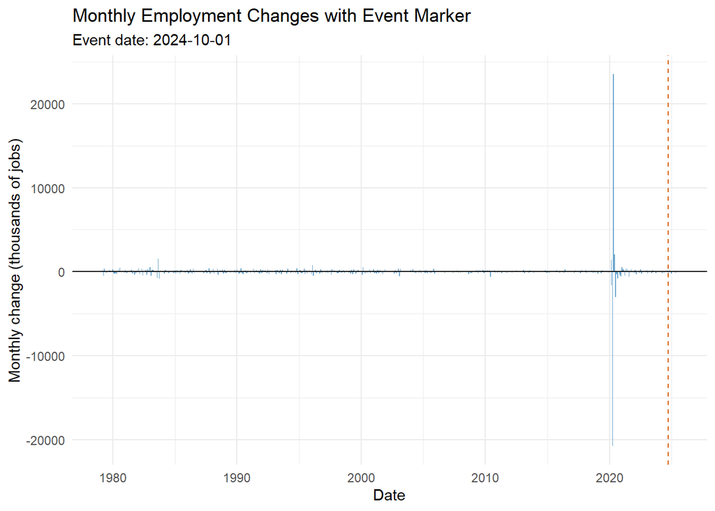

```r
library(ggplot2)
library(scales)

# 1) Monthly changes over time with event line
ggplot(df_changes, aes(x = date, y = monthly_change)) +
  geom_col(fill = "#2C7FB8", alpha = 0.7) +
  geom_hline(yintercept = 0, color = "black") +
  geom_vline(xintercept = event_date, linetype = "dashed", color = "#D95F0E") +
  labs(
    title = "Monthly Employment Changes with Event Marker",
    subtitle = paste("Event date:", event_date),
    x = "Date",
    y = "Monthly change (thousands of jobs)"
  ) +
  theme_minimal()
```

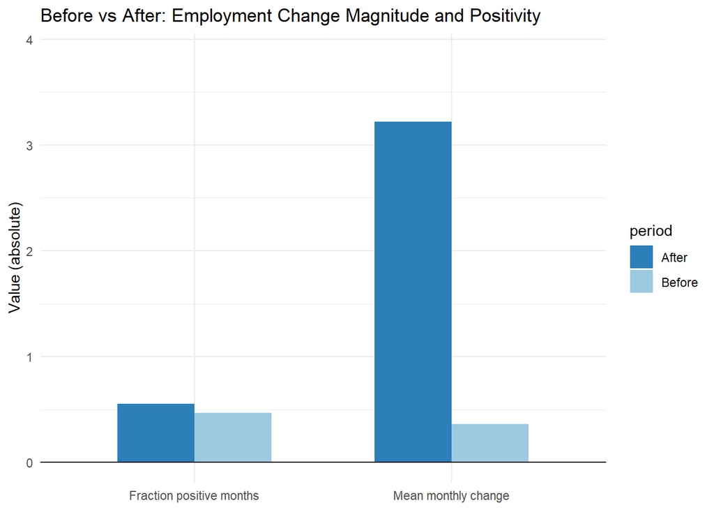

```r
# 2) Before vs After comparison of key statistics
stats_long <- stats_by_period %>%
  select(period, mean_monthly_change, frac_positive_months) %>%
  tidyr::pivot_longer(-period, names_to = "metric", values_to = "value") %>%
  mutate(
    metric = recode(metric,
                    mean_monthly_change = "Mean monthly change",
                    frac_positive_months = "Fraction positive months"),
    value = abs(value)   # ensure no negative values
  )

ggplot(stats_long, aes(x = metric, y = value, fill = period)) +
  geom_col(position = position_dodge(width = 0.6), width = 0.6) +
  geom_hline(yintercept = 0, linetype = "solid", color = "black") +  # reference line at 0
  scale_y_continuous(labels = comma, limits = c(0, max(stats_long$value) * 1.2)) +
  scale_fill_manual(values = c("Before" = "#9ecae1", "After" = "#2C7FB8")) +
  labs(
    title = "Before vs After: Employment Change Magnitude and Positivity",
    x = NULL,
    y = "Value (absolute)"
  ) +
  theme_minimal() +
  theme(axis.text.x = element_text(angle = 0, hjust = 0.5))
```